# Doing cross-validation using `library(caret)`

Víctor Peña

In this document, I’ll show you how to use `library(caret)` to perform cross-validation. This package has implementations of other ways of evaluating out-of-sample performance which we won’t cover here. You can learn more by going to the [official website of `library(caret)`](https://topepo.github.io/caret/index.html) (there is a lot of information).

# Classification

I’ll assume that the `titanic` dataset that is used in the course [“Introduction to Machine Learning with `R`”](https://campus.datacamp.com/courses/introduction-to-machine-learning-with-r/) is already loaded in. I’ll use a 60/40 train-test split. I’ll use cross-validation on the training set to tune the parameters of decision trees (`rpart`), $k$-nearest neighbors (`knn`), and random forests. Then, I’ll compare the performance of the classifiers on the held-out test set with ROC curves.

First of all, I load all the packages that we’ll need:

```r
library(caret)
library(randomForest)
library(e1071)
library(rattle)
library(rpart.plot)
library(RColorBrewer)
library(ROCR)
```

Now, I do the 60/40 train-test split randomly:

```r
set.seed(123)
ntrain = round(0.6*nrow(titanic))
tr_idx = sample(1:ntrain)
titanic_train = titanic[tr_idx, ]
titanic_test = titanic[-(tr_idx), ]
```

Doing `nfold` cross-validation with `library(caret)` is as straightforward as following this general recipe:

```r
model <- train(
  response ~ predictors,
  data,
  method = "your method",
  trControl = trainControl(
    method = "cv",
    number = nfold,
  )
)
```

The argument `method` tells `caret` which method we want to use (for example, if we want to fit a decision tree, `method = "rpart"`). Then, `number` is the number of folds.

## Decision trees

Decision trees have a complexity parameter `cp` which needs to be pre-specified. I’ll use 6-fold cross-validation to pick `cp`. The metric I’ll use to quantify model performance will be accuracy (which is the default metric in `library(caret)`).

```r
nfold = 6
mod_tree = train(Survived ~ . ,
                 data = titanic_train,
                 method = "rpart",
                 trControl = trainControl(
                   method = "cv",
                   number = nfold))
```

Let’s inspect the output:

```r
mod_tree
```

```
## CART
##
## 428 samples
##   2 predictor
##   2 classes: '0', '1'
##
## No pre-processing
## Resampling: Cross-Validated (6 fold)
## Summary of sample sizes: 357, 357, 356, 356, 358, 356, ...
## Resampling results across tuning parameters:
##
##   cp          Accuracy   Kappa
##   0.01734104  0.6494299  0.2215592
##   0.04335260  0.6333249  0.2352797
##   0.11560694  0.5934468  0.0945216
##
## Accuracy was used to select the optimal model using the largest value.
## The final value used for the model was cp = 0.01734104.
```

What happened under the hood is the following: `library(caret)` tried out some values of `cp`, estimated their out-of-sample accuracy via cross-validation, and picked the value of `cp` that gave the highest accuracy.

We can find the in-sample confusion table easily:

```r
confusionMatrix(mod_tree)
```

```
## Cross-Validated (6 fold) Confusion Matrix
##
## (entries are percentual average cell counts across resamples)
##
##           Reference
## Prediction    0    1
##          0 50.5 25.9
##          1  9.1 14.5
##
##  Accuracy (average) : 0.6495
```

Note that this is using data on the training set only.

We can also plot the decision tree as follows:

[figure not shown]

```r
fancyRpartPlot(mod_tree$finalModel)
```

## $k$-nearest neighbors

As you know, if you want to use $k$-nearest neighbors, you have to specify $k$ in advance. I’ll use 6-fold cross-validation, using accuracy as the metric to quantify how the classifier is, to decide what $k$ I’ll use.

```r
nfold = 6
mod_knn = train(Survived ~ . ,
                data = titanic_train,
                method = "knn",
                trControl = trainControl(
                  method = "cv",
                  number = nfold))
```

Now, we can look at the output:

```r
mod_knn
```

```
## k-Nearest Neighbors
##
## 428 samples
##   2 predictor
##   2 classes: '0', '1'
##
## No pre-processing
## Resampling: Cross-Validated (6 fold)
## Summary of sample sizes: 356, 357, 356, 357, 356, 358, ...
## Resampling results across tuning parameters:
##
##   k  Accuracy   Kappa
##   5  0.5886849  0.1108996
##   7  0.6003903  0.1192037
##   9  0.6193681  0.1564380
##
## Accuracy was used to select the optimal model using the largest value.
## The final value used for the model was k = 9.
```

It’s telling us which value of $k$ it picked. Now, we can find the in-sample confusion matrix just as we did in the previous section:

```r
confusionMatrix(mod_knn)
```

```
## Cross-Validated (6 fold) Confusion Matrix
##
## (entries are percentual average cell counts across resamples)
##
##           Reference
## Prediction    0    1
##          0 48.6 27.1
##          1 11.0 13.3
##
##  Accuracy (average) : 0.6192
```

## Random forests

Random forests are, in some sense, averages of decision trees. The idea is resampling our own data a few times, find decision trees for each resample, and then ``average.’’ In practice, they’re classifiers that are often robust and perform well. If you want to know more about random forests, you can check out [this video](https://www.youtube.com/watch?v=J4Wdy0Wc_xQ).

Random forests have parameters that need to be tuned. We’ll tune them using 6-fold cross-validation.

This code trains the model:

```r
mod_rf = train(Survived ~ . ,
               data = titanic_train,
               method = "rf",
               trControl = trainControl(
                 method = "cv",
                 number = nfold))
```

And we can find the in-sample confusion table just as we did before for other methods:

```r
confusionMatrix(mod_rf)
```

```
## Cross-Validated (6 fold) Confusion Matrix
##
## (entries are percentual average cell counts across resamples)
##
##           Reference
## Prediction    0    1
##          0 45.1 22.0
##          1 14.5 18.5
##
##  Accuracy (average) : 0.6355
```

## Comparing models using ROC curves

Now, it’s time to compare the performance of decision-trees, $k$-nearest neighbors, and random forests in the test set. First of all, we’ll find the predicted probabilities of survival in the test set:

```r
probs_t = predict(mod_tree, titanic_test, type = "prob")[,2]
probs_k = predict(mod_knn, titanic_test, type = "prob")[,2]
probs_rf = predict(mod_rf, titanic_test, type = "prob")[,2]
```

We’ll plot the ROC curves using `library(ROCR)`. For that, we need to call `prediction()` and then `performance()`:

```r
pred_t = prediction(probs_t, titanic_test$Survived)
pred_k = prediction(probs_k, titanic_test$Survived)
pred_rf = prediction(probs_rf, titanic_test$Survived)

perf_t = performance(pred_t, "tpr", "fpr")
perf_k = performance(pred_k, "tpr", "fpr")
perf_rf = performance(pred_rf, "tpr", "fpr")
```

Now, we’re in good shape to plot the ROC curves:

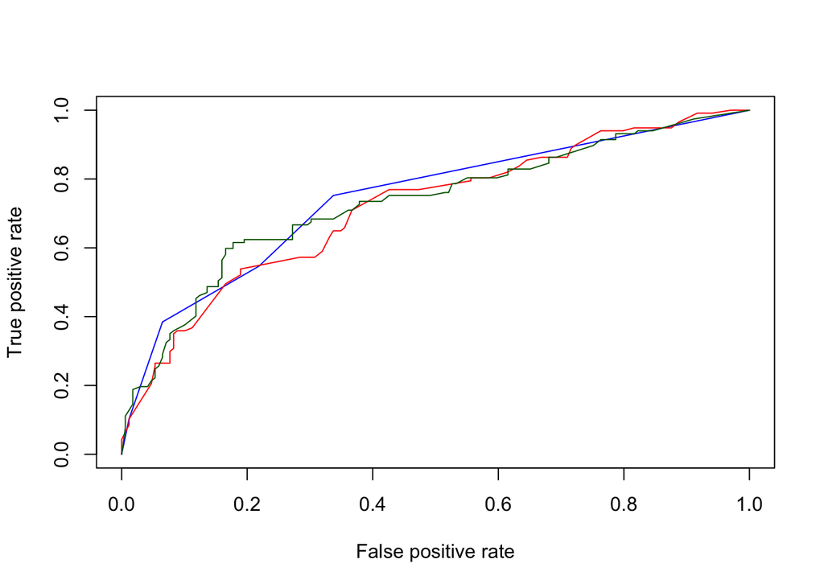

```r
plot(perf_t, col = "blue")
plot(perf_k, col = "red", add = TRUE)
plot(perf_rf, col = "darkgreen", add = TRUE)
```

As you can see, $k$-nearest neighbors seems to be the worst-performing method here, while decision trees and random forests are pretty close.

The same conclusions can be reached after finding the areas under the curve (AUC) associated with the ROC curves:

```r
performance(pred_t, "auc")@y.values[[1]]
```

```
## [1] 0.7427047
```

```r
performance(pred_k, "auc")@y.values[[1]]
```

```
## [1] 0.7161786
```

```r
performance(pred_rf, "auc")@y.values[[1]]
```

```
## [1] 0.7298336
```

# Regression

We can use the same recipe we used with classification to compare out-of-sample performance of competing regression models.

We’ll use the `diamonds` dataset, which contains the prices of some diamonds, along with some other information. Our goal will be predicting the price of a diamond, given all the other variables in the dataset.

First, we load in the data:

```r
data(diamonds)
```

Now, let’s use 10-fold cross-validation to evaluate the out-of-sample performance of a linear regression model where the response is `price` and the predictors are all the other variables:

```r
model_lm <- train(
  price ~ .,
  diamonds,
  method = "lm",
  trControl = trainControl(
    method = "cv",
    number = 10,
  )
)
```

Let’s print the output:

```r
model_lm
```

```
## Linear Regression
##
## 53940 samples
##     9 predictor
##
## No pre-processing
## Resampling: Cross-Validated (10 fold)
## Summary of sample sizes: 48545, 48545, 48547, 48546, 48547, 48546, ...
## Resampling results:
##
##   RMSE      Rsquared   MAE
##   1130.782  0.9196589  740.6297
##
## Tuning parameter 'intercept' was held constant at a value of TRUE
```

This output gives us cross-validated estimates of RMSE, Rsquared, and MAE (mean absolute error).

Let’s compare this with the performance of a smaller model:

```r
model_small <- train(
  price ~ carat + cut + color + clarity + depth + table + x + z,
  diamonds,
  method = "lm",
  trControl = trainControl(
    method = "cv",
    number = 10,
  )
)
```

Let’s print out the output:

```r
model_small
```

```
## Linear Regression
##
## 53940 samples
##     8 predictor
##
## No pre-processing
## Resampling: Cross-Validated (10 fold)
## Summary of sample sizes: 48545, 48545, 48545, 48547, 48547, 48546, ...
## Resampling results:
##
##   RMSE      Rsquared   MAE
##   1130.544  0.9197121  740.4165
##
## Tuning parameter 'intercept' was held constant at a value of TRUE
```

It seems that the smaller model is slightly better, but only marginally.